GeoStat Lab · M10 · Previsione e progetto statistico

M10_N15 · Futura

# Stabilità e residui del sistema

5 blocchi R eseguiti4 grafici0 errori · 0 avvisiOffline · MathML

Codice, output e figure dello stesso svolgimento. Ogni notebook riparte dai dati locali ed è autonomo rispetto agli altri.

# La domanda

La dinamica stimata si attenua e quali scarti rimangono?

## Obiettivi

- Calcolare gli autovalori della matrice VAR.
- Confrontare i moduli con uno.
- Esaminare residui contemporanei e temporali.

**Prima di iniziare.** Sono richiesti vettori, tabelle e funzioni R di base. I blocchi vanno eseguiti in ordine. Il notebook è autonomo rispetto agli altri.

**Dati e unità.** Processi sintetici di 300 passi, senza unità fisica. Le colonne x_VAR e y_VAR costituiscono un sistema bivariato. Usiamo i passi 1–250 per stimare e, quando richiesto, 251–260 per una previsione a origine fissa. La prima riga è una condizione iniziale finita: l’esempio non equivale a una nuova serie osservativa.

## Preparazione

Aprire il progetto autonomo di Futura o quello generale del corso. I calcoli usano R base e stats. Gli output del notebook vanno in `Risultati/M10_N15/`; i CSV originali restano invariati.

Codice R · preparazione

```r
# Trova la cartella M10 dal progetto autonomo o dal progetto generale.
.gs_cerca <- normalizePath(getwd(),winslash="/",mustWork=TRUE)
repeat {
  .gs_candidati <- c(.gs_cerca,
    file.path(.gs_cerca,"M10_Futura"),
    file.path(.gs_cerca,"03_Notebook_svolti","M10_Futura"),
    file.path(.gs_cerca,"M10","03_Notebook_svolti","M10_Futura"))
  .gs_ok <- file.exists(file.path(.gs_candidati,"M10_N01.Rmd")) &
    file.exists(file.path(.gs_candidati,"R","funzioni_notebook.R"))
  if(any(.gs_ok)) { .gs_modulo <- .gs_candidati[which(.gs_ok)[1L]]; break }
  .gs_padre <- dirname(.gs_cerca)
  if(.gs_padre==.gs_cerca) stop("Aprire il progetto M10_Futura o quello generale dei notebook.")
  .gs_cerca <- .gs_padre
}
source(file.path(.gs_modulo,"R","funzioni_notebook.R"),local=TRUE)
.gs_funzioni <- .gs_prepara_notebook(.gs_modulo,"M10_N15")
carica_dati <- .gs_funzioni$carica_dati
percorso_risultati <- .gs_funzioni$percorso_risultati
options(width=88,digits=6)
if(requireNamespace("knitr",quietly=TRUE)) {
  knitr::opts_chunk$set(echo=TRUE,error=FALSE,warning=TRUE,message=TRUE,
    fig.width=8,fig.height=5,dpi=150,fig.align="center")
}
set.seed(10015)
```

## 1. La stabilità riguarda la matrice

Per un VAR(1) la dinamica è stabile quando tutti gli autovalori di A hanno modulo inferiore a uno. La condizione riguarda il modello stimato.

Codice R · passo_01

```r
p <- carica_dati("processi_simulati.csv")
mod <- stima_var(p)
ev <- eigen(mod$A,only.values=TRUE)$values
data.frame(parte_reale=Re(ev),parte_immaginaria=Im(ev),modulo=Mod(ev))
data.frame(stabile=all(Mod(ev)<1))
```

Output eseguito

```
  parte_reale parte_immaginaria   modulo
1    0.513873                 0 0.513873
2    0.309782                 0 0.309782
  stabile
1    TRUE
```

**Lettura del risultato.** Una singola stima stabile non dimostra che ogni meccanismo reale sia stabile. Nel dataset sintetico conosciamo il contesto di simulazione, ma restano variabilità campionaria e avvio finito.

## 2. Gli scarti possono condividere uno shock

La correlazione contemporanea fra residui X e Y è diversa dall’autocorrelazione nel tempo.

Codice R · passo_02

```r
rx <- residuals(mod$fit_x); ry <- residuals(mod$fit_y)
cov(cbind(X=rx,Y=ry))
cor(rx,ry)
stile_grafico()
plot(rx,ry,pch=19,col=palette_geo[1],xlab="Residuo X",ylab="Residuo Y",
     main="Scarti contemporanei del sistema")
abline(h=0,v=0,lty=2,col="grey60")
```

Output eseguito

```
           X          Y
X  0.9089526 -0.0281267
Y -0.0281267  1.1244438
[1] -0.0278214
```

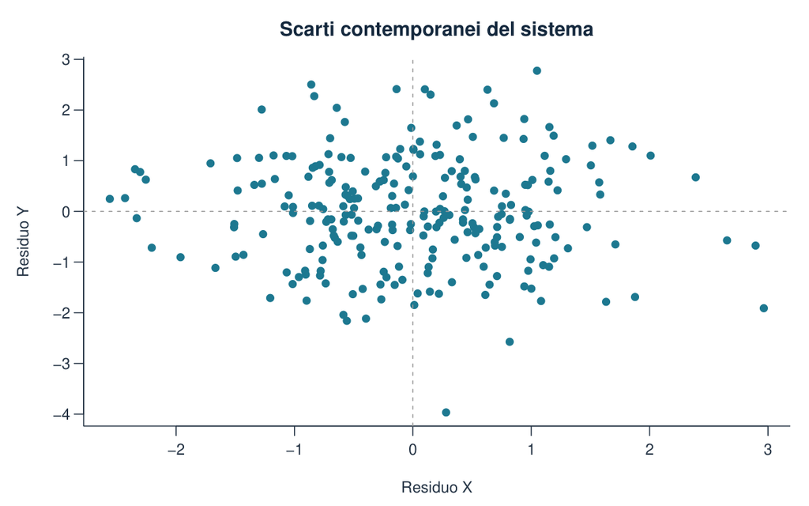

Figura 1 · Output del blocco `passo_02`. PDF vettoriale.

**Lettura del risultato.** Una covarianza contemporanea richiede attenzione nell’incertezza congiunta. Non identifica da sola la direzione di una relazione fisica.

## 3. La successione verifica memoria residua

Le ACF delle due equazioni conservano la scala dei ritardi.

Codice R · passo_03

```r
stile_grafico(); acf(rx,lag.max=20,main="VAR: ACF residui equazione X")
stile_grafico(); acf(ry,lag.max=20,main="VAR: ACF residui equazione Y")
data.frame(equazione=c("X","Y"),n=c(length(rx),length(ry)),
           media=c(mean(rx),mean(ry)),sd=c(sd(rx),sd(ry)))
```

Output eseguito

```
  equazione   n        media      sd
1         X 249 -3.28692e-17 0.95339
2         Y 249 -4.81995e-17 1.06040
```

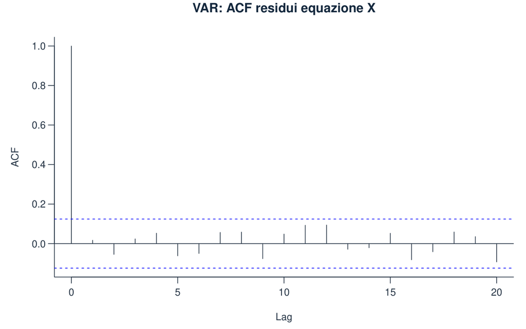

Figura 2 · Output del blocco `passo_03`. PDF vettoriale.

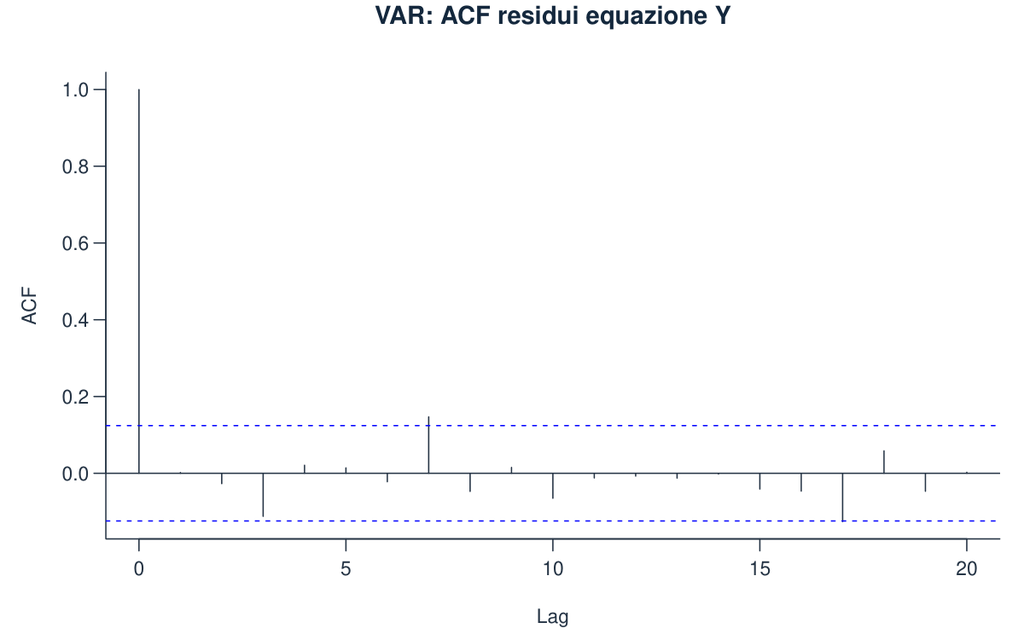

Figura 3 · Output del blocco `passo_03`. PDF vettoriale.

**Lettura del risultato.** Residui con memoria suggeriscono una specifica incompleta. Grafici e test devono considerare la struttura del sistema e la stima dei parametri.

## Variante svolta

**Propagare una perturbazione nota.** Conservare la matrice stimata e osservare come evolve uno scostamento iniziale unitario in X, senza aggiungere innovazioni.

Codice R · variante

```r
stato <- c(1,0)
risposta <- matrix(NA_real_,21,2)
risposta[1,] <- stato
for(k in 1:20) { stato <- as.numeric(mod$A%*%stato); risposta[k+1,] <- stato }
head(data.frame(h=0:20,X=risposta[,1],Y=risposta[,2]),6)
stile_grafico()
matplot(0:20,risposta,type="l",lty=1,col=palette_geo[1:2],
  xlab="Passi",ylab="Scostamento dal riferimento",main="Propagazione deterministica con A stimata")
abline(h=0,lty=2)
```

Output eseguito

```
  h         X         Y
1 0 1.0000000 0.0000000
2 1 0.4744882 0.5965605
3 2 0.2316260 0.4913597
4 3 0.1152467 0.3097451
5 4 0.0580513 0.1769042
6 5 0.0294683 0.0964001
```

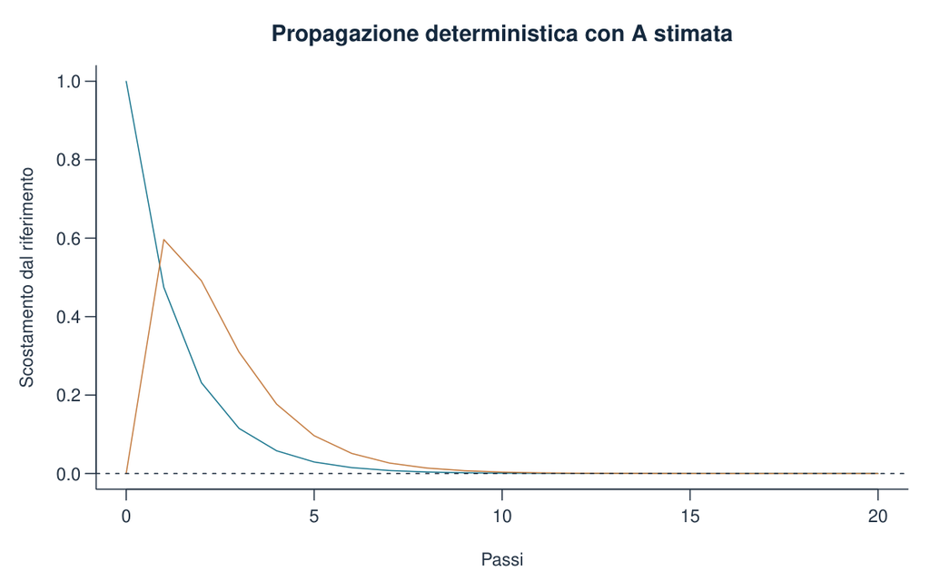

Figura 4 · Output del blocco `variante`. PDF vettoriale.

Questa è una perturbazione dello stato, non un impulso strutturale identificato. Confronta la dinamica della matrice senza introdurre un’interpretazione causale.

## Errore da riconoscere

Controllare separatamente i coefficienti diagonali e trascurare gli autovalori dell’intera matrice.

## Risposta alla domanda

La stabilità dipende dal sistema complessivo. La diagnosi dei residui completa la verifica e mantiene distinta la dipendenza contemporanea dalla memoria temporale.

## Riferimento nel corso

Questo svolgimento sviluppa il laboratorio `M10_N15` di [GeoStat Lab M10](https://marzione00.github.io/Lab_Geo/#indice). Il [codice originale del laboratorio](https://github.com/marzione00/Lab_Geo/blob/649f7cc577b96bd1044d81e78a2f530813e4f96b/materiali/laboratori/M10/M10_N15.R) è conservato anche in `R/Originali_corso`. Gli ampliamenti e le varianti sono identificati nella mappa allegata.

Documentazione dei metodi: [R stats, arima](https://stat.ethz.ch/R-manual/R-devel/library/stats/html/arima.html), [predict.Arima](https://stat.ethz.ch/R-manual/R-devel/library/stats/html/predict.arima.html), [Box.test](https://stat.ethz.ch/R-manual/R-devel/library/stats/html/box.test.html) e [p.adjust](https://stat.ethz.ch/R-manual/R-devel/library/stats/html/p.adjust.html).